# mantelNSGA2 vignette

```r
library(mantelNSGA2)
library(vegan)
data("varechem")
data("varespec")
```

# 1 Introduction

## 1.1 The BIO-ENV approach

The **mantelNSGA2** package was created to facilitate the efficient search of explanatory variables for use in a BIOENV-like analysis (Clarke and Ainsworth 1993). BIO-ENV explores the correlation between two multivariate data sets via a [Mantel test](https://en.wikipedia.org/wiki/Mantel_test) according to pairwise similarity (or distance) values between samples. One of the data sets is *fixed*, i.e. all variables are includes in its similarity matrix, while the other data set’s variables are *varied* across all combinations to try and identify subsets variables whose similarity best correlates to that of the fixed data set similarity. Correlations may be based either on Pearson or Spearman correlations, with the latter being preferred in community analysis due to it’s non-parametric nature. Likewise, choice of similarity metrics may also be important in non-parametric situations (e.g. Bray-Curtis similarity).

The vegan package’s `bioenv` function assumes the typical BIO-ENV setup, i.e. a fixed biological data set and a variable environmental data set whose similarity matrix is based on normalized Euclidean distance. This makes sense with environmental data where one normalizes the data to remove the effect of differing units between parameters. The fixed biological data similarity uses the non-parametric Bray-Curtis similarity by default, but other metrics may be used.

Beyond the typical BIO-ENV configuration, other types exist that require additional flexibility in defining the similarity metrics of both data sets:

- ENV-BIO: subset of biological variables that best correlate to the overall environmental pattern
- BIO-BIO: subset of biological variables that best correlate to the overall biological pattern
- ENV-ENV: subset of environmental variables that best correlate to the overall environmental pattern

This flexibility is allowed by the `bioEnv` function of the sinkr, which is also included in `mantelNSGA2`, through arguments `fix.dist.method` and `var.dist.method`.

## 1.2 Efficient search with BV-STEP

The BIO-ENV methodology involves an exhaustive testing of all possible combinations of the variable data set. For some analysis, e.g. BIO-BIO involving a large number of taxa, this may result in a an unrealistically-large number of tests ($2^n - 1$). For this reason, Clarke and Warwick (1998) presented a stepwise routine, called *BV-STEP* (see `bvStep`) for more efficient exploration of the subset combinations. The method employs a *forward-backward* search approach to adding/removing variables. When many variables exist, it is also recommended to only start with a much smaller subset for the start of the stepwise procedure (e.g. `random.selection = TRUE` and `prop.selected.var = 0.1` for using 10% of randomly-selected variables at each start).

The number of resulting combinations per subset of variables is dome-shaped, such that many more combinations exist when ca 50% of variables are used. The steepness of this dome is more extreme for a higher number of variables:

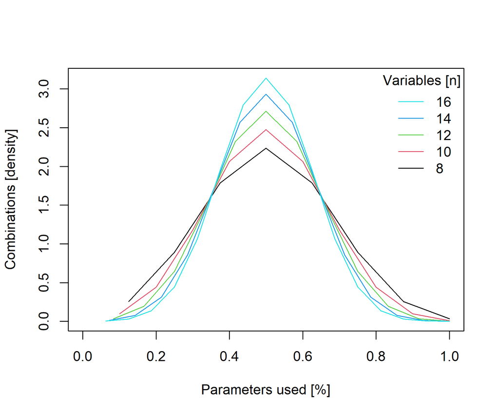

```r
trapzfun <- function(x, y){
  idx = 2:length(x)
  return(as.double((x[idx] - x[idx - 1]) %*% (y[idx] + y[idx -
    1]))/2)
}
nvar <- c(8, 10, 12, 14, 16)
RES <- vector("list", length(nvar))
names(RES) <- nvar
for(j in seq(nvar)){
  res <- seq(nvar[j])*NaN
  for(i in seq(res)){
    res[i] <- ncol(combn(seq(length(res)), i))
  }
  RES[[j]] <- res/trapzfun(x = seq(res)/length(res), y = res)
}

ylim = c(0, max(do.call("c", RES)))
for(j in seq(RES)){
  if(j == 1){
    plot(seq(RES[[j]])/length(RES[[j]]), RES[[j]], ylim = ylim, xlim = c(0,1),
      xlab = "Parameters used [%]", ylab = "Combinations [density]", t = "n")
  }
  lines(seq(RES[[j]])/length(RES[[j]]), RES[[j]], col = j)
}
legend("topright", legend = rev(nvar), col = rev(seq(nvar)), lty = 1, title = "Variables [n]", bty = "n")
```

$$\\[0in]$$

For most analysis, it is of interest to be able to quantify the relative importance of variables best correlating to the fixed data set. In `bioEnv`and `bvStep`, results are reported in terms of the best correlating combinations and best model per number of variables, which may help in defining the most parsimonious models. Thus, identifying simpler models containing less variables are likely to be of higher priority than higher order combinations where improvements to correlation are marginal. For `bvStep`, a typical strategy might be to include only a small proportion of variables at each restart in order to efficiently explore the lower parameter space.

## 1.3 Efficient search with mantelNSGA2

An more efficient search is offered by `mantelNSGA2` by means of a [genetic algorithm](https://en.wikipedia.org/wiki/Genetic_algorithm) search combined with the concept of a [Pareto front](https://en.wikipedia.org/wiki/Pareto_front), used to focus the search on the most parsimonious model configurations. The genetic algorithm is used to identify the best scoring combinations of the variable data set, coded by “genes” for their inclusion in each individual of the population. Only the individuals with the best genetic “fitness” are permitted to contribute to the next generation of offspring, which may contain new genetic coding of variable combinations.

Similar to the demonstration above regarding the number of possible combinations by complexity, a random selection of initial gene combinations in the starting population would produce a bias towards intermediate complexity:

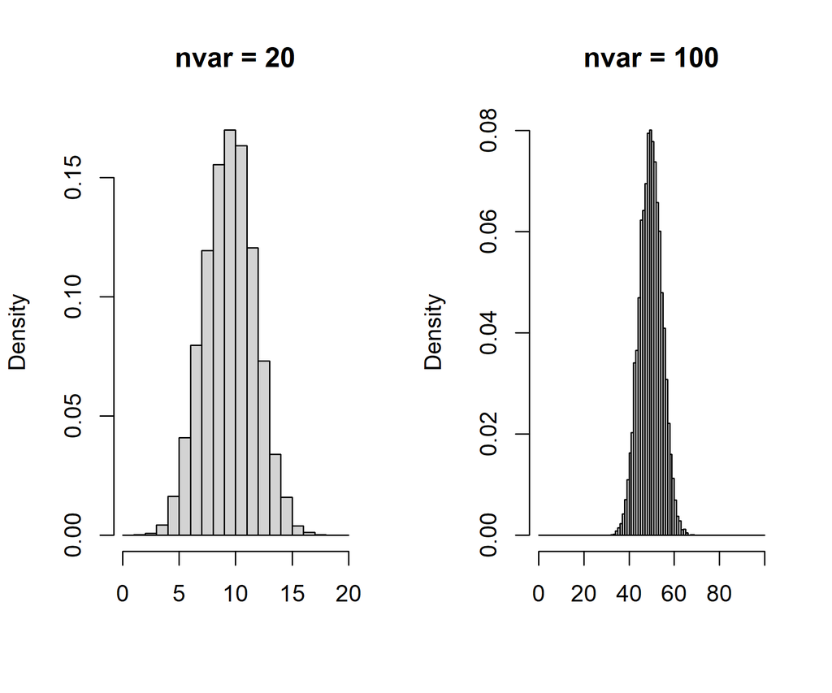

```r
op <- par(mfcol = c(1,2))
# chance of having few or many "genes" turned on is low, so one ends up
# mainly exploring the middle
nvar <- 20
tmp <- replicate(10000, expr = sum(sample(x = c(0,1), nvar, replace = TRUE)))
hist(tmp, breaks = seq(0, nvar), freq = FALSE, xlab = "", main = paste("nvar =", nvar))

# more extreme when number of genes is high
nvar <- 100
tmp <- replicate(10000, expr = sum(sample(x = c(0,1), nvar, replace = TRUE)))
hist(tmp, breaks = seq(0, nvar), freq = FALSE, xlab = "", main = paste("nvar =", nvar))
```

```r
par(op)
```

$$\\$$

Therefore, the `mantelNSGA2` approach initializes only single or a few genes in the initial population to again more fully explore parsimonious solutions before moving on to more complex ones. The NSGA2 approach also ensures that leading candidate solutions along the Pareto (i.e. for each level of model complexity) are carried on to the next generation and allowed to reproduce. To further improve the search efficiency, [memoization](https://en.wikipedia.org/wiki/Memoization) is used to store tested genetic combinations and prevent repeated evaluations in later generations. The following examples present two different configurations, ENV-BIO and BIO-BIO, comparing the performance between `bvStep` and `mantelNSGA2`. Both examples use data from the ´vegan´ package; specifically, the environmental `varechem` data (n = 14 variables) and the biological `varespec` data (n = 44 variables). The biological data is used as the variable set in both examples. A full BIO-ENV exploration would require $n = 2^{44}-1 = 1.76e13$ combinations, making such an analysis unreasonable.

# 2 Examples

## 2.1 ENV-BIO example

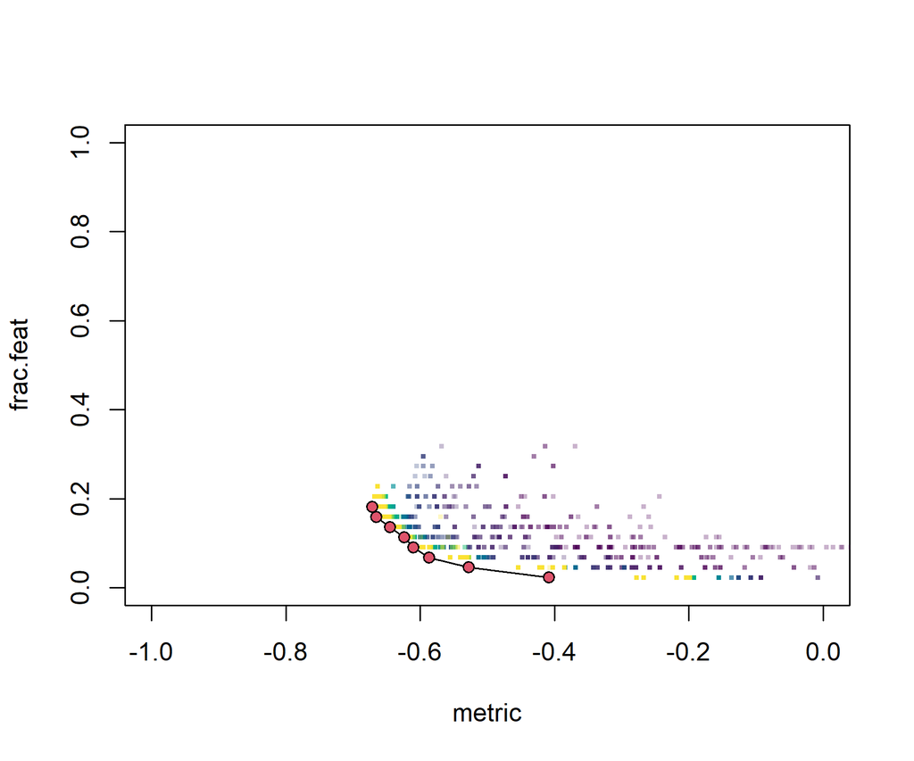

```r
# biological community variables that best correlate with environmental data
fix.mat = varechem
var.mat = wisconsin(varespec)
fix.dist.method = "euclidean"
var.dist.method = "bray"
scale.fix = TRUE
scale.var = FALSE
p.feat <- 0.1

# mantelNSGA2
set.seed(1111)
fitGA <- mantelNSGA2(
  fix.mat = fix.mat, var.mat = var.mat,
  fix.dist.method = fix.dist.method, var.dist.method = var.dist.method,
  scale.fix = scale.fix, scale.var = scale.var, p.feat = p.feat,
  pop.size = 50, max.iter = 100, stop.criterion = 50,
  mutation.rate = 0.2, crossover.rate = 0.8, verbose = FALSE
)
# plot(fitGA$generation.fitness)
# fitGA$pareto.solution
plot(fitGA, parFrontT = "o")
```

```r
fitGA$pareto.solution
```

|  | ID | metric | frac.feat | nr.of.params | dist.to.CoordOrigin | vars |
| --- | --- | --- | --- | --- | --- | --- |
| 4 | 4 | -0.4084377 | 0.0227273 | 1 | 0.5919988 | 15 |
| 1 | 1 | -0.5272613 | 0.0454545 | 2 | 0.4749189 | 23,29 |
| 2 | 2 | -0.5869494 | 0.0681818 | 3 | 0.4186401 | 23,29,37 |
| 8 | 8 | -0.6103121 | 0.0909091 | 4 | 0.4001514 | 23,29,37,44 |
| 5 | 5 | -0.6237154 | 0.1136364 | 5 | 0.3930691 | 9,23,29,37,44 |
| 6 | 6 | -0.6447397 | 0.1363636 | 6 | 0.3805325 | 1,15,23,29,37,44 |
| 3 | 3 | -0.6649700 | 0.1590909 | 7 | 0.3708841 | 1,9,15,23,29,37,44 |
| 7 | 7 | -0.6711006 | 0.1818182 | 8 | 0.3758094 | 1,9,15,23,29,37,41,44 |

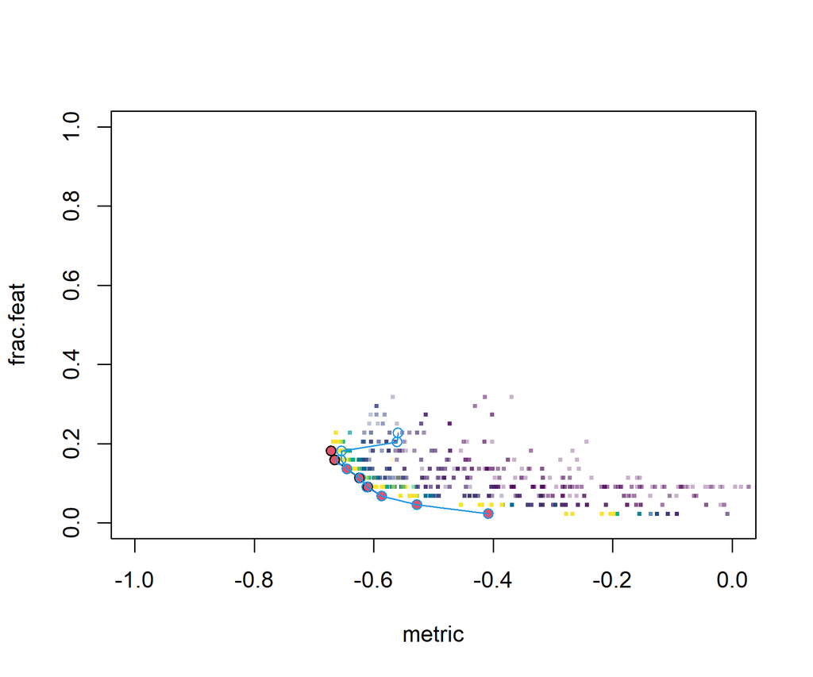

```r
# Compare to bvStep
set.seed(1111)
fitBV <- bvStep(
  fix.mat = fix.mat, var.mat = var.mat,
  fix.dist.method = fix.dist.method, var.dist.method = var.dist.method,
  scale.fix = scale.fix, scale.var = scale.var,
  num.restarts = 50,
  random.selection = TRUE,
  prop.selected.var = 0.4,
  verbose = FALSE
)
# fitBV$order.by.best # mantelGA not looking in simpler solutions enough
# fitBV$order.by.i.comb
plot(fitGA, parFrontT = "o")
points(-fitBV$order.by.i.comb$rho, fitBV$order.by.i.comb$n.var/ncol(var.mat), pch = 1, col = 4, t = "o")
```

## 2.2 BIO-BIO example

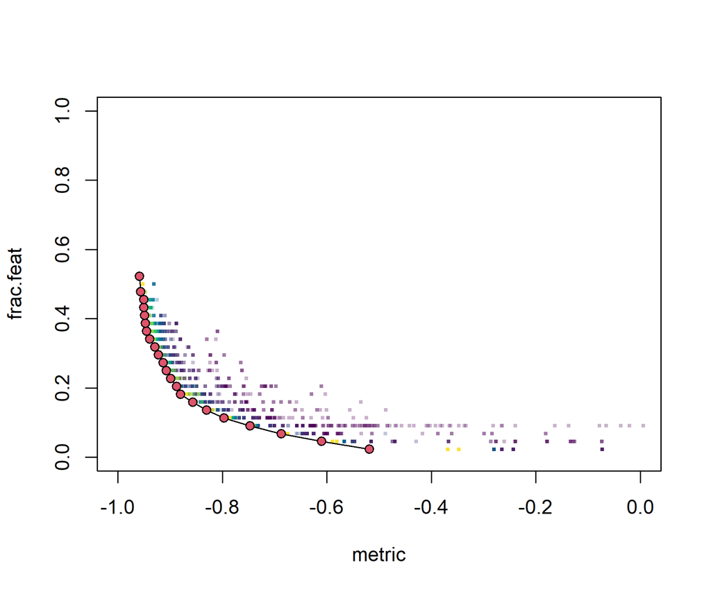

```r
# biological community variables that best correlate with the
# overall biological community
fix.mat = wisconsin(varespec)
var.mat = wisconsin(varespec)
fix.dist.method = "bray"
var.dist.method = "bray"
scale.fix = FALSE
scale.var = FALSE
p.feat <- 0.1

# mantelNSGA2
set.seed(1111)
fitGA2 <- mantelNSGA2(
  fix.mat = fix.mat, var.mat = var.mat,
  fix.dist.method = fix.dist.method, var.dist.method = var.dist.method,
  scale.fix = scale.fix, scale.var = scale.var, p.feat = p.feat,
  pop.size = 50, max.iter = 100, stop.criterion = 50,
  mutation.rate = 0.2, crossover.rate = 0.8, verbose = FALSE
)
# plot(fitGA2$generation.fitness)
# fitGA2$pareto.solution
plot(fitGA2, parFrontT = "o")
```

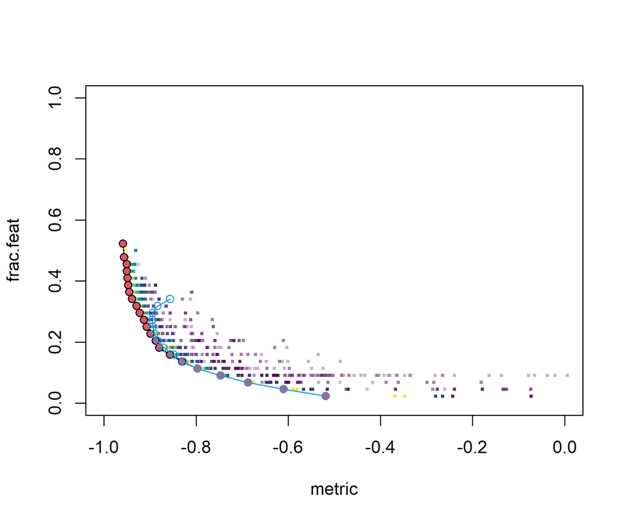

```r
# Compare to bvStep
set.seed(1111)
fitBV2 <- bvStep(
  fix.mat = fix.mat, var.mat = var.mat,
  fix.dist.method = fix.dist.method, var.dist.method = var.dist.method,
  scale.fix = scale.fix, scale.var = scale.var,
  num.restarts = 50,
  random.selection = TRUE,
  prop.selected.var = 0.3,
  var.always.include = c(15,23,26),
  verbose = FALSE
)
# fitBV2$order.by.best # mantelGA not looking in simpler solutions enough
# fitBV2$order.by.i.comb
plot(fitGA2, parFrontT = "o")
points(-fitBV2$order.by.i.comb$rho, fitBV2$order.by.i.comb$n.var/ncol(var.mat), pch = 1, col = 4, t = "o")
```

# References

Clarke, K. R., and M Ainsworth. 1993. “A Method of Linking Multivariate Community Structure to Environmental Variables.” *Marine Ecology Progress Series* 92: 205–19. https://doi.org/10.3354/meps092205.

Clarke, K. R., and R. M. Warwick. 1998. “Quantifying Structural Redundancy in Ecological Communities.” *Oecologia* 113 (2): 278–89. https://doi.org/10.1007/s004420050379.